# cp2021-F08-Q05

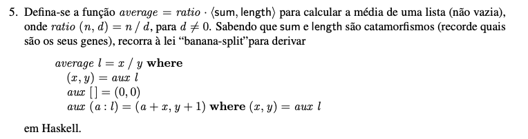

### Resolução

$\def\cata#1{\mathopen{(\!|}#1\mathclose{|\!)}}\def\kons#1{\underline{#1}}$

Sejam $sum = \cata{[\kons{0},add]}$, $length = \cata{[\kons{0},succ . \pi_2]}$, $in = [\kons{[]},cons]$ e $F f = B \ (id,f) = id + id \times f$.

E seja $\alpha = <sum , length >$

{ $sum = \cata{[\kons{0},add]}$, $length = \cata{[\kons{0},succ . \pi_2]}$ }

$\equiv \alpha = <\cata{[\kons{0},add]}, \cata{[\kons{0},succ . \pi_2]}>$

{ **banana-split, lei (53)** }

$\equiv \alpha = \cata{([\kons{0},add] \times [\kons{0},succ . \pi_2]) \ . <F \pi_1, F \pi_2>}$

{ **absorção-**$\times$ }

$\equiv \alpha = \cata{<[\kons{0},add] . F \pi_1, [\kons{0},succ . \pi_2] . F \pi_2>}$

{ $F f = id + id \times f$ }

$\equiv \alpha = \cata{<[\kons{0},add] . (id + id \times \pi_1), [\kons{0},succ . \pi_2] . (id + id \times \pi_2)>}$

{ **absorção-+**; **natural-id** }

$\equiv \alpha = \cata{<[\kons{0} ,add . (id \times \pi_1)], [\kons{0},succ . \pi_2 . (id \times \pi_2)]>}$

{ **universal-cata, lei (45)** }

$\equiv \alpha . in = <[\kons{0} ,add . (id \times \pi_1)], [\kons{0},succ . \pi_2 . (id \times \pi_2)]> \ . F \alpha$

{ **lei da troca, lei (28)**; $F f = id + id \times f$; $in = [\kons{[]},cons]$ }

$\equiv \alpha . [\kons{[]},cons] = [<\kons{0}, \kons{0}> , <add . (id \times \pi_1), succ . \pi_2 . (id \times \pi_2)>] \ . (id + id \times \alpha)$

{ **fusão-+**; **absorção-+**; **natural-id** }

$\equiv [\alpha . \kons{[]}, \alpha . cons] = [<\kons{0}, \kons{0}> , <add . (id \times \pi_1), succ . \pi_2 . (id \times \pi_2)> \ . (id \times \alpha)]$

{ **eq-+**; **natural-**$-\pi_2$ }

$\alpha . \kons{[]} = <\kons{0}, \kons{0}>$

$\alpha . cons = <add . (id \times \pi_1), succ . \pi_2 . \pi_2> \ . (id \times \alpha)$

{ **pointwise** ; **def-const** ; **def-split** }

$\alpha \ [] = (0,0)$

$\alpha \ (h:t) = (add . (id \times \pi_1)) \ (h,\alpha \ t) , succ . \pi_2 . \pi_2) \ (h,\alpha \ t))$

{ **def-comp** }

$\alpha \ [] = (0,0)$

$\alpha \ (h:t) = (add (h, \pi_1 (\alpha \ t)) , succ (\pi_2 (\alpha \ t)))$

{ $add \ (x,y) = x + y$; $succ \ n = n + 1$ }

$\alpha \ [] = (0,0)$

$\alpha \ (h:t) = (h + \pi_1 (\alpha \ t) , \pi_2 (\alpha \ t) + 1)$

Ou seja,

$average \ l = x \ / \ y \ where \ (x,y) = \alpha \ l$

```haskell
-- loading CP libs
:opt no-lint
:load ../src/Cp.hs
:load ../src/Nat.hs
:set -XNPlusKPatterns
```

```haskell
alfa [] = (0,0)
alfa (h:t) = (h + p1(alfa t), p2(alfa t) + 1)

average l = x / y
    where (x,y) = alfa l

average [2,3,4,7,9,3]
```

```
4.666666666666667
```

```haskell
cata g ([x]) = g . i1 $ x
cata g (h:t) = g . i2 $ (h,cata g t)
:t cata
```

cata :: forall a b. (Either a (a, b) -> b) -> [a] -> b

```haskell
-- sum

g = either (const 0) (uncurry (+))
:t g

-- testing

cata g [2,3,4,5,6,7]
```

g :: forall c b. Num c => Either b (c, c) -> c

```
20
```

```haskell
-- length

g = either (const 0) (succ . p2)
:t g

-- testing

cata g [2,3,4,5,6,7]
```

g :: forall c b a. (Num c, Enum c) => Either b (a, c) -> c

```
5
```

```haskell
g = either (split id (const 1)) (split ((uncurry (+)) . (id >< p1)) (succ . p2 . (id >< p2)))
```

```haskell
:t g
```

g :: forall c b. (Num c, Num b, Enum c) => Either b (b, (b, c)) -> (b, c)

```haskell
ratio (n,d) = n/d
average = ratio . cata g
average [2,3,4,7,9,3]
```

```
4.666666666666667
```